# Assignment_4_kMeans_Clustering

SrushtiP

10/27/2019

Problem Statement:

The dataset on American College and University Rankings contains information on 1302 American colleges and universities offering an undergraduate program. For each university, there are 17 measurements, including continuous measurements (such as tuition and grad- uation rate) and categorical measurements (such as location by state and whether it is a private or public school). Note that many records are missing some measurements.

kMeans Clustering : It is an unsupervised learning algorithm. K-means algorithm identifies k number of centroids, and then allocates every data point to the nearest cluster, while keeping the centroids as small as possible.

- The libraries required to proceed with the solution by implementing the k Means Clustering algorithm.

```r
library(ISLR)
library(dplyr)
library(tidyverse)
library(factoextra)
library(flexclust)
```

```r
library(ggplot2)
```

The data file Universities.csv is read below and the data is stored in a variable.

```r
University <- read.csv("Universities.csv")

University$Public..1...Private..2. <- factor(University$Public..1...Private..2., levels = c(1,2), labels = c("Public","Private"))
```

- The Data related to “Tufts University” is stored in a variable.

```r
Tufts_university <- University[which(University$College.Name == "Tufts University"),]
```

Q 1.) Remove all records with missing measurements from the dataset.

- There are lots of missing value in the dataset thus to compute the clustering algorithm we have to remove the missing records from the dataset.

```r
University <- na.omit(University)
summary(University)
```

```
##                    College.Name     State     Public..1...Private..2.
##  Trinity College         :  4   PA     : 42   Public :128
##  Augustana College       :  2   NY     : 38   Private:343
##  Monmouth College        :  2   OH     : 24
##  University of St. Thomas:  2   NC     : 23
##  Westminster College     :  2   MA     : 22
##  Adams State College     :  1   TX     : 20
##  (Other)                 :458   (Other):302
##  X..appli..rec.d X..appl..accepted X..new.stud..enrolled
##  Min.   :   77   Min.   :   61.0   Min.   :  27.0
##  1st Qu.:  802   1st Qu.:  635.5   1st Qu.: 264.0
##  Median : 1646   Median : 1227.0   Median : 443.0
##  Mean   : 3147   Mean   : 2063.0   Mean   : 780.7
##  3rd Qu.: 3862   3rd Qu.: 2456.0   3rd Qu.: 896.5
##  Max.   :48094   Max.   :26330.0   Max.   :6392.0
##
##  X..new.stud..from.top.10. X..new.stud..from.top.25. X..FT.undergrad
##  Min.   : 1.00             Min.   :  9.00            Min.   :  249
##  1st Qu.:15.00             1st Qu.: 40.00            1st Qu.: 1018
##  Median :23.00             Median : 54.00            Median : 1715
##  Mean   :28.01             Mean   : 55.65            Mean   : 3563
##  3rd Qu.:36.00             3rd Qu.: 69.00            3rd Qu.: 4056
##  Max.   :96.00             Max.   :100.00            Max.   :31643
##
##  X..PT.undergrad   in.state.tuition out.of.state.tuition      room
##  Min.   :    1.0   Min.   :  608    Min.   : 1044        Min.   : 640
##  1st Qu.:   81.5   1st Qu.: 3650    1st Qu.: 7290        1st Qu.:1740
##  Median :  299.0   Median : 9858    Median :10100        Median :2090
##  Mean   :  797.5   Mean   : 9407    Mean   :10575        Mean   :2221
##  3rd Qu.:  869.0   3rd Qu.:13246    3rd Qu.:13286        3rd Qu.:2663
##  Max.   :21836.0   Max.   :20100    Max.   :20100        Max.   :4816
##
##      board        add..fees      estim..book.costs estim..personal..
##  Min.   : 531   Min.   :  10.0   Min.   :  90.0    Min.   : 250
##  1st Qu.:1750   1st Qu.: 137.5   1st Qu.: 500.0    1st Qu.: 850
##  Median :2082   Median : 280.0   Median : 500.0    Median :1200
##  Mean   :2122   Mean   : 379.0   Mean   : 548.8    Mean   :1312
##  3rd Qu.:2420   3rd Qu.: 486.0   3rd Qu.: 600.0    3rd Qu.:1600
##  Max.   :4541   Max.   :3247.0   Max.   :2340.0    Max.   :6800
##
##  X..fac..w.PHD    stud..fac..ratio Graduation.rate
##  Min.   :  8.00   Min.   : 2.90    Min.   : 15.00
##  1st Qu.: 63.00   1st Qu.:11.30    1st Qu.: 53.00
##  Median : 76.00   Median :13.40    Median : 66.00
##  Mean   : 73.21   Mean   :13.96    Mean   : 65.56
##  3rd Qu.: 87.00   3rd Qu.:16.45    3rd Qu.: 79.00
##  Max.   :103.00   Max.   :28.80    Max.   :118.00
##
```

As per the descriptive statistics we can see that the NA values are all removes and number of observations are reduced from 1302 to 471 observations.

Q 2.) For all the continuous measurements, run K-Means clustering. Make sure to normalize the measurements. How many clusters seem reasonable for describing these data? What was your optimal K?

- To normalized the dataset we have scale the continuous variables of the date by its z-score.

```r
Normalized_University <- scale(University[c(-1,-2,-3)])
```

To compute the optimal k value we can use:

- With-In-Sum-Of-Squares (WSS) method. WSS is a measure to explain the homogeneity within a cluster. WSS is the total distance of data points from their respective cluster centroids
- Average Silhouette measures the quality of a clustering,it determines how well each object lies within its cluster. A high average silhouette width indicates a good clustering.

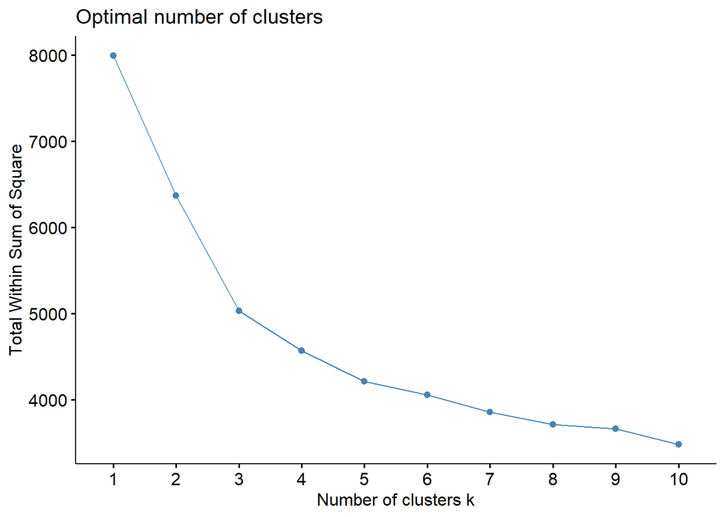

```r
fviz_nbclust(Normalized_University, kmeans, method = "wss")
```

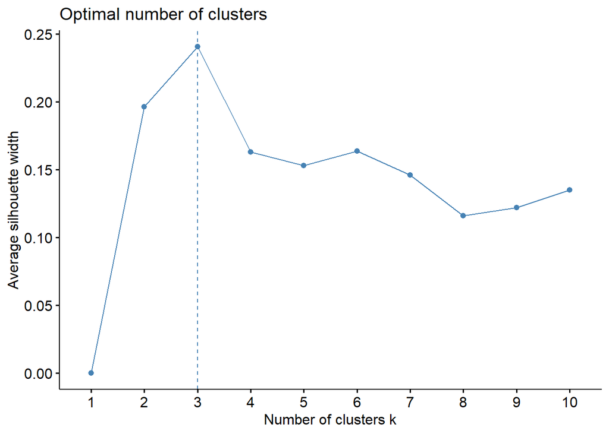

```r
fviz_nbclust(Normalized_University, kmeans, method = "silhouette")
```

Here if we look carefully, the optimal solution for k value is computed as 3. Therefore, we can now use this k = 3 to apply the k means clustering algorithm on the dataset. However considering thecatagorical measurements the reasonable number of cluster to be formed should be 2 for Private College and Public Colleges.

Q 3.) Compare the summary statistics for each cluster and describe each cluster in this context (e.g., “Universities with high tuition, low acceptance rate…”).

```r
k_means <- kmeans(Normalized_University, centers = 3, nstart = 50)

View(k_means$centers)
k_means$size
```

```
## [1] 275 150  46
```

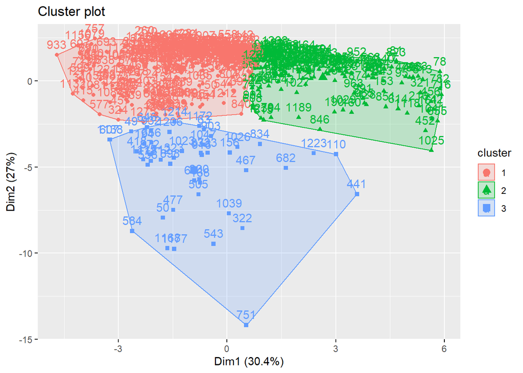

```r
fviz_cluster(k_means, data = Normalized_University)
```

Based on the computed summary of the clusters we can predict the below conclusions:

- Cluster 1 : Below Average College.

**~ Applications received - Low**

Application Accepted - Low

New Enrollement - Low

Percentage of new students from top 10% - Low

Percentage of new students from top 25% - Low

Full Time undergrade - Low

Part Time undergrade - Low

In state tution - Average

Out state tution - Average

Room Cost - Average

Boards - Average

Additional fees - Low

Estimated Book Cost - Low

Estimated Personal Expenses - Average

Faculty with PHD - Average

Student/Facult Ratio - Average

Graduation Rate - Low

**Cluster 2 : Best Average.**

Applications received - Average

Application Accepted - Average

New Enrollement - Average

Percentage of new students from top 10% - High

Percentage of new students from top 25% - High

Full Time undergrade - Average

Part Time undergrade - Average

In state tution - High

Out state tution - High

Room Cost - High

Boards - High

Additional fees - Average

Estimated Book Cost - Average

Estimated Personal Expenses - Low

Faculty with PHD - High

Student/Facult Ratio - Low

Graduation Rate - High

**Cluster 3 : Average College.**

Applications received - High

Application Accepted - High

New Enrollement - High

Percentage of new students from top 10% - Average

Percentage of new students from top 25% - Average

Full Time undergrade - High

Part Time undergrade - High

Out state tution - Average

Room Cost - Low

Boards - Low

Additional fees - High

Estimated Book Cost - High

Estimated Personal Expenses - High

Student/Facult Ratio - High

Graduation Rate - Average

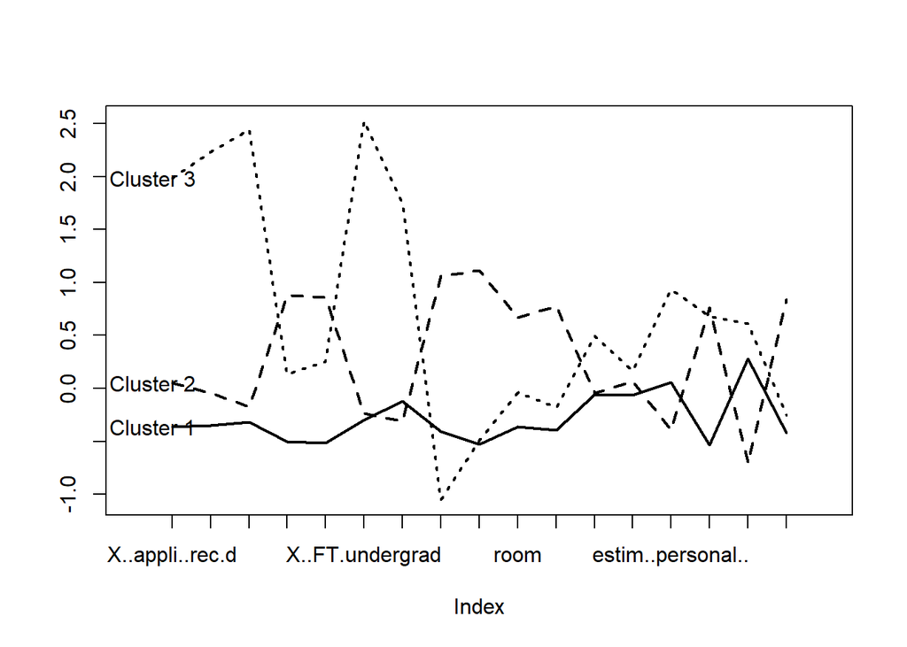

```r
plot(c(0), xaxt = 'n', ylab = "", type = "l", ylim = c(min(k_means$centers), max(k_means$centers)), xlim = c(0, 18))
axis(1, at = c(1:17), labels = colnames(k_means$centers))

for (i in c(1:3))
  lines(k_means$centers[i,], lty = i, lwd = 2, col = ifelse(i %in% c(1, 2, 3),"black", "dark grey"))

text(x = 0.5, y = k_means$centers[, 1], labels = paste("Cluster", c(1:3)))
```

Q 4.) Use the categorical measurements that were not used in the analysis (State and Private/Public) to characterize the different clusters. Is there any relationship between the clusters and the categorical information?

- To determine the relationship between the clusters and the catagorical data we have bind the column with the University Dataset.

```r
University_kMeans <- cbind(University, Cluster_Status = k_means$cluster)

University_kMeans$Cluster_Status <- factor(University_kMeans$Cluster_Status, levels = c(1,2,3), labels = c("Below Average Colleges","Average Colleges", "Best Colleges"))

head(University_kMeans)
```

```
##                           College.Name State Public..1...Private..2.
## 1            Alaska Pacific University    AK                 Private
## 3       University of Alaska Southeast    AK                  Public
## 10         Birmingham-Southern College    AL                 Private
## 12                  Huntingdon College    AL                 Private
## 22                   Talladega College    AL                 Private
## 26 University of Alabama at Birmingham    AL                  Public
##    X..appli..rec.d X..appl..accepted X..new.stud..enrolled
## 1              193               146                    55
## 3              146               117                    89
## 10             805               588                   287
## 12             608               520                   127
## 22            4414              1500                   335
## 26            1797              1260                   938
##    X..new.stud..from.top.10. X..new.stud..from.top.25. X..FT.undergrad
```

[output cut: 27 more lines]

The data is determined in the tabular format and the relationship between the Catagorical mesurements within the clusters are presented.

```r
table(University_kMeans$State, University_kMeans$Cluster_Status)
```

```
##
##      Below Average Colleges Average Colleges Best Colleges
##   AK                      2                0             0
##   AL                      3                1             0
##   AR                      4                0             0
##   AZ                      0                0             2
##   CA                      3               10             2
##   CO                      5                1             0
##   CT                      3                6             1
##   DC                      0                4             0
##   DE                      1                0             1
##   FL                      3                4             1
##   GA                      4                2             1
##   HI                      1                0             0
##   IA                     16                2             0
##   ID                      2                0             0
##   IL                      7                6             2
##   IN                      8                7             0
##   KS                      7                0             0
##   KY                      4                2             0
##   LA                      2                2             1
##   MA                      7               12             3
##   MD                      1                1             1
##   ME                      4                2             0
##   MI                      7                4             2
##   MN                      6                4             1
##   MO                     12                2             1
##   MS                      5                0             0
##   MT                      2                0             0
##   NC                     16                3             4
##   ND                      5                0             0
##   NE                      5                1             1
##   NH                      4                1             1
##   NJ                      9                3             1
##   NM                      2                0             0
##   NV                      0                0             0
##   NY                     18               18             2
##   OH                     13                7             4
##   OK                      5                0             1
##   OR                      1                4             0
##   PA                     19               20             3
##   RI                      1                2             1
##   SC                      7                2             0
##   SD                      4                0             0
##   TN                     11                3             1
##   TX                     14                2             4
##   UT                      1                0             1
##   VA                      8                4             3
##   VT                      5                2             0
##   WA                      0                2             0
##   WI                      5                4             0
##   WV                      2                0             0
##   WY                      1                0             0
```

```r
table(University_kMeans$Public..1...Private..2., University_kMeans$Cluster_Status)
```

```
##
##           Below Average Colleges Average Colleges Best Colleges
##   Public                      84                3            41
##   Private                    191              147             5
```

Q 5.) What other external information can explain the contents of some or all of these clusters?

```r
Below_Average_Universities <- University_kMeans[University_kMeans$Cluster_Status == "Below Average Colleges", c(1,2,3,21)]
View(Below_Average_Universities)

Average_Universities <- University_kMeans[University_kMeans$Cluster_Status == "Average Colleges", c(1,2,3,21)]
View(Average_Universities)

Best_Universities <- University_kMeans[University_kMeans$Cluster_Status == "Best Colleges", c(1,2,3,21)]
View(Best_Universities)

prop.table(table(University_kMeans$Public..1...Private..2., University_kMeans$Cluster_Status))*100
```

```
##
##           Below Average Colleges Average Colleges Best Colleges
##   Public              17.8343949        0.6369427     8.7048832
##   Private             40.5520170       31.2101911     1.0615711
```

```r
k_means$totss
```

```
## [1] 7990
```

```r
k_means$withinss
```

```
## [1] 2562.342 1424.892 1044.680
```

```r
k_means$betweenss
```

```
## [1] 2958.086
```

```r
k_means$iter
```

```
## [1] 3
```

- Total-Sum-of-Squares (TSS): TSS is the total distance of data points from global mean of data, for a given dataset this quantity is going to be constant = 7990
- With-in-Sum-of-Squares (WSS): WSS is the total distance of data points from their respective cluster centroid = Cluster 1 : 2562.342, Cluster 2 : 1424.892, Cluster 3 : 1044.680
- Between-Sum-of-Squares (BSS): BSS is the total weighted distance of various cluster centroids to the global mean of data = 2958.086
- Iter: The number of (outer) iterations = 3

Q 6.) Consider Tufts University, which is missing some information. Compute the Euclidean distance of this record from each of the clusters that you found above (using only the measurements that you have). Which cluster is it closest to? Impute the missing values for Tufts by taking the average of the cluster on those measurements.

- Here, we have added a row of Tufts University which we have computed above and added the mean value of the data in place of the missing values in the dataset.

```r
dist(rbind(Tufts_university[, c(-1, -2, -3, -10)], k_means$centers[1,]))
```

```
##        476
## 2 29819.09
```

```r
dist(rbind(Tufts_university[, c(-1, -2, -3, -10)], k_means$centers[2,]))
```

```
##       476
## 2 29817.8
```

```r
dist(rbind(Tufts_university[, c(-1, -2, -3, -10)], k_means$centers[3,]))
```

```
##        476
## 2 29816.76
```

Accordingto the distance that we have calculated we can see that the Distance between the records from Tufts Universit and the Cluster 3 is minimum.

Here, we are calculatng the mean of the PT Undergrade Column of Cluster 3 and replacing it in the Tufs University’s Missing Value.

```r
Cluster_Data <- filter(University_kMeans, University_kMeans$Cluster_Status == "Best Colleges")
Tufts_university$X..PT.undergrad <- mean(Cluster_Data[,c(10)])
```

```r
Data <- rbind(University, Tufts_university)
dim(Data)
```

```
## [1] 472  20
```

- The data needs to be normalized based on the same method (scale i.e. z-score) as the kMeans Model we have computed above.

```r
Data_normalized <- scale(Data[c(-1,-2,-3)])
```

- Applying the kMeans Clustering Model with optimal k = 3. Later, we have bind the Tufts University data with the cluster it falls under after the k means Clustering model is applied

```r
k_means_Tufts <- kmeans(Data_normalized, centers = 3, nstart = 50)

cbind(Tufts_university, Cluster = tail(k_means_Tufts$cluster, 1))
```

```
##         College.Name State Public..1...Private..2. X..appli..rec.d
## 476 Tufts University    MA                 Private            7614
##     X..appl..accepted X..new.stud..enrolled X..new.stud..from.top.10.
## 476              3605                  1205                        60
##     X..new.stud..from.top.25. X..FT.undergrad X..PT.undergrad
## 476                        90            4598        3500.565
##     in.state.tuition out.of.state.tuition room board add..fees
## 476            19701                19701 3038  2930       503
##     estim..book.costs estim..personal.. X..fac..w.PHD stud..fac..ratio
## 476               600               928            99             10.3
##     Graduation.rate Cluster
## 476              92       3
```